# Peer Assessment I

First, let us load the data and necessary packages:

```r
load("ames_train.Rdata")
library(MASS)
library(dplyr)
library(ggplot2)
```

# 1

Make a labeled histogram (with 30 bins) of the ages of the houses in the data set, and describe the distribution.

```r
ames_train %>% summarise(min = min(Year.Built), max = max(Year.Built), mean = mean(Year.Built), median = median(Year.Built), sd = sd(Year.Built)) #102 distinct values
```

```
## # A tibble: 1 × 5
##     min   max     mean median       sd
##   <int> <int>    <dbl>  <dbl>    <dbl>
## 1  1872  2010 1972.203   1975 29.63741
```

```r
2010-1872
```

```
## [1] 138
```

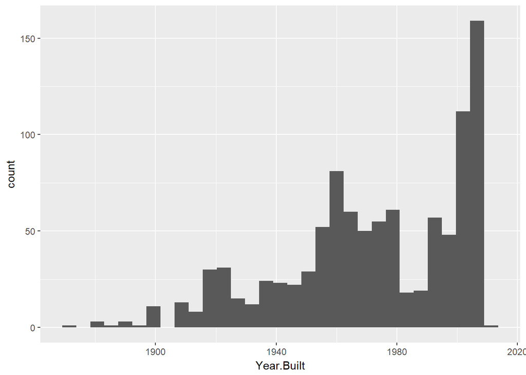

```r
# Create a histogram with 30 bins of Year.Built
ggplot(data = ames_train, aes(Year.Built)) + geom_histogram(binwidth = (140/30))
```

# 2

The mantra in real estate is “Location, Location, Location!” Make a graphical display that relates a home price to its neighborhood in Ames, Iowa. Which summary statistics are most appropriate to use for determining the most expensive, least expensive, and most heterogeneous (having the most variation in housing price) neighborhoods? Report which neighborhoods these are based on the summary statistics of your choice. Report the value of your chosen summary statistics for these neighborhoods.

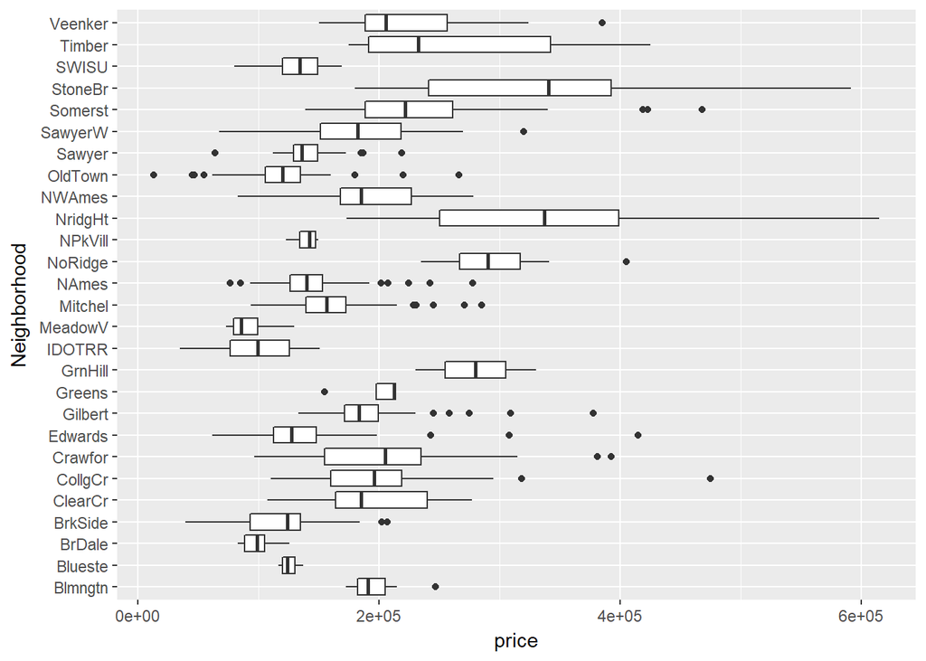

```r
ggplot(data = ames_train, aes(Neighborhood, price)) + geom_boxplot() + coord_flip()
```

```r
summary_stats <-
  ames_train %>%
  filter(!is.na(price)) %>%
  group_by(Neighborhood) %>%
  summarise(min = min(price), max = max(price), mean = mean(price), median = median(price), sd = sd(price))
```

# 3

Which variable has the largest number of missing values? Explain why it makes sense that there are so many missing values for this variable.

```r
missing <- sapply(ames_train, function(x) sum(is.na(x)))
missing[missing>0]
```

```
##   Lot.Frontage          Alley   Mas.Vnr.Area      Bsmt.Qual      Bsmt.Cond
##            167            933              7             21             21
##  Bsmt.Exposure BsmtFin.Type.1   BsmtFin.SF.1 BsmtFin.Type.2   BsmtFin.SF.2
##             21             21              1             21              1
##    Bsmt.Unf.SF  Total.Bsmt.SF Bsmt.Full.Bath Bsmt.Half.Bath   Fireplace.Qu
##              1              1              1              1            491
##    Garage.Type  Garage.Yr.Blt  Garage.Finish    Garage.Cars    Garage.Area
##             46             48             46              1              1
##    Garage.Qual    Garage.Cond        Pool.QC          Fence   Misc.Feature
##             47             47            997            798            971
```

Pool.QC seems to have the most missing data (997 cases), which makes sense, as this value would only be filled if the property has a pool. Misc.Feature, Alley, Fence, and Fireplace.Qu also have a large number of missing values, which is also expected as those fields represent non-required features of a property, where missing values indicates an absence of those features.

# 4

We want to predict the natural log of the home prices. Candidate explanatory variables are lot size in square feet (Lot.Area), slope of property (Land.Slope), original construction date (Year.Built), remodel date (Year.Remod.Add), and the number of bedrooms above grade (Bedroom.AbvGr). Pick a model selection or model averaging method covered in the Specialization, and describe how this method works. Then, use this method to find the best multiple regression model for predicting the natural log of the home prices.

```r
model_base <- lm(data = ames_train, log(price) ~ Lot.Area + Land.Slope + Year.Built + Year.Remod.Add + Bedroom.AbvGr)

model2 <- model2 <- lm(data = ames_train, log(price) ~ Lot.Area + Year.Built + Year.Remod.Add + Bedroom.AbvGr)
model3 <- model2 <- lm(data = ames_train, log(price) ~ Lot.Area + Land.Slope + Year.Remod.Add + Bedroom.AbvGr)
model4 <- model2 <- lm(data = ames_train, log(price) ~ Lot.Area + Land.Slope + Year.Built + Bedroom.AbvGr)
model5 <- model2 <- lm(data = ames_train, log(price) ~ Lot.Area + Land.Slope + Year.Built + Year.Remod.Add)
model6 <- lm(data = ames_train, log(price) ~ Land.Slope + Year.Built + Year.Remod.Add + Bedroom.AbvGr)
model_results <- data.frame(c("model_base", "model2", "model3", "model4", "model5", "model6"), c(summary(model_base)$adj.r.squared, summary(model2)$adj.r.squared, summary(model3)$adj.r.squared, summary(model4)$adj.r.squared, summary(model5)$adj.r.squared, summary(model6)$adj.r.squared))
names(model_results) <- c("model", "adj.r.squared")
model_results
```

```
##        model adj.r.squared
## 1 model_base     0.5598345
## 2     model2     0.5314859
## 3     model3     0.4473663
## 4     model4     0.4922384
## 5     model5     0.5314859
## 6     model6     0.5220090
```

```r
summary(model_base)
```

```
##
## Call:
## lm(formula = log(price) ~ Lot.Area + Land.Slope + Year.Built +
##     Year.Remod.Add + Bedroom.AbvGr, data = ames_train)
##
## Residuals:
##     Min      1Q  Median      3Q     Max
## -2.0878 -0.1651 -0.0211  0.1657  0.9945
##
## Coefficients:
##                  Estimate Std. Error t value Pr(>|t|)
## (Intercept)    -1.371e+01  8.574e-01 -15.996  < 2e-16 ***
## Lot.Area        1.028e-05  1.106e-06   9.296  < 2e-16 ***
## Land.SlopeMod   1.384e-01  4.991e-02   2.773  0.00565 **
## Land.SlopeSev  -4.567e-01  1.514e-01  -3.016  0.00263 **
## Year.Built      6.049e-03  3.788e-04  15.968  < 2e-16 ***
## Year.Remod.Add  6.778e-03  5.468e-04  12.395  < 2e-16 ***
## Bedroom.AbvGr   8.686e-02  1.077e-02   8.063 2.12e-15 ***
## ---
## Signif. codes:  0 '***' 0.001 '**' 0.01 '*' 0.05 '.' 0.1 ' ' 1
##
## Residual standard error: 0.279 on 993 degrees of freedom
## Multiple R-squared:  0.5625, Adjusted R-squared:  0.5598
## F-statistic: 212.8 on 6 and 993 DF,  p-value: < 2.2e-16
```

# 5

Which home has the largest squared residual in the previous analysis (Question 4)? Looking at all the variables in the data set, can you explain why this home stands out from the rest (what factors contribute to the high squared residual and why are those factors relevant)?

```r
comparison <- data.frame(model_base$fitted.values, ames_train$price)
comparison <- comparison %>% mutate(sq.residual = model_base.fitted.values - log(ames_train.price))
comparison %>% filter(sq.residual == max(sq.residual))
```

```
##   model_base.fitted.values ames_train.price sq.residual
## 1                 11.54419            12789    2.087853
```

```r
#ames_train %>% filter(price == 12789)
```

# 6

Use the same model selection method you chose in Question 4 to again find the best multiple regression model to predict the natural log of home prices, but this time **replacing Lot.Area with log(Lot.Area)**. Do you arrive at a model including the same set of predictors?

```r
model_base <- lm(data = ames_train, log(price) ~ log(Lot.Area) + Land.Slope + Year.Built + Year.Remod.Add + Bedroom.AbvGr)


model2 <- model2 <- lm(data = ames_train, log(price) ~ log(Lot.Area) + Year.Built + Year.Remod.Add + Bedroom.AbvGr)
model3 <- model2 <- lm(data = ames_train, log(price) ~ log(Lot.Area) + Land.Slope + Year.Remod.Add + Bedroom.AbvGr)
model4 <- model2 <- lm(data = ames_train, log(price) ~ log(Lot.Area) + Land.Slope + Year.Built + Bedroom.AbvGr)
model5 <- model2 <- lm(data = ames_train, log(price) ~ log(Lot.Area) + Land.Slope + Year.Built + Year.Remod.Add)
model6 <- lm(data = ames_train, log(price) ~ Land.Slope + Year.Built + Year.Remod.Add + Bedroom.AbvGr)
model_results <- data.frame(c("model_base", "model2", "model3", "model4", "model5", "model6"), c(summary(model_base)$adj.r.squared, summary(model2)$adj.r.squared, summary(model3)$adj.r.squared, summary(model4)$adj.r.squared, summary(model5)$adj.r.squared, summary(model6)$adj.r.squared))
names(model_results) <- c("model", "adj.r.squared")
model_results
```

```
##        model adj.r.squared
## 1 model_base     0.6032018
## 2     model2     0.5910888
## 3     model3     0.4932282
## 4     model4     0.5363921
## 5     model5     0.5910888
## 6     model6     0.5220090
```

```r
summary(model_base)
```

```
##
## Call:
## lm(formula = log(price) ~ log(Lot.Area) + Land.Slope + Year.Built +
##     Year.Remod.Add + Bedroom.AbvGr, data = ames_train)
##
## Residuals:
##      Min       1Q   Median       3Q      Max
## -2.14050 -0.15650 -0.01561  0.15350  0.90854
##
## Coefficients:
##                  Estimate Std. Error t value Pr(>|t|)
## (Intercept)    -1.553e+01  8.197e-01 -18.947  < 2e-16 ***
## log(Lot.Area)   2.442e-01  1.708e-02  14.297  < 2e-16 ***
## Land.SlopeMod   1.151e-01  4.734e-02   2.431   0.0152 *
## Land.SlopeSev  -6.554e-02  1.222e-01  -0.536   0.5917
## Year.Built      5.981e-03  3.597e-04  16.628  < 2e-16 ***
## Year.Remod.Add  6.734e-03  5.190e-04  12.975  < 2e-16 ***
## Bedroom.AbvGr   5.909e-02  1.055e-02   5.599  2.8e-08 ***
## ---
## Signif. codes:  0 '***' 0.001 '**' 0.01 '*' 0.05 '.' 0.1 ' ' 1
##
## Residual standard error: 0.2649 on 993 degrees of freedom
## Multiple R-squared:  0.6056, Adjusted R-squared:  0.6032
## F-statistic: 254.1 on 6 and 993 DF,  p-value: < 2.2e-16
```

# 7

Do you think it is better to log transform Lot.Area, in terms of assumptions for linear regression? Make graphs of the predicted values of log home price versus the true values of log home price for the regression models selected for Lot.Area and log(Lot.Area). Referencing these two plots, provide a written support that includes a quantitative justification for your answer in the first part of question 7.

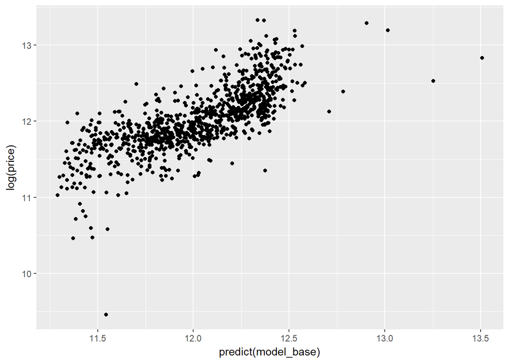

```r
model_base <- lm(data = ames_train, log(price) ~ Lot.Area + Land.Slope + Year.Built + Year.Remod.Add + Bedroom.AbvGr)
model_base_log <- lm(data = ames_train, log(price) ~ log(Lot.Area) + Land.Slope + Year.Built + Year.Remod.Add + Bedroom.AbvGr)
ggplot(ames_train, aes(predict(model_base), log(price))) + geom_point()
```

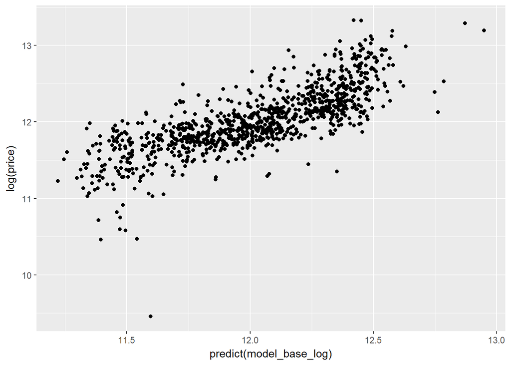

```r
ggplot(ames_train, aes(predict(model_base_log), log(price))) + geom_point()
```

Graphs of the predicted natural logs of home prices from the models against the actual home prices suggest that the model that uses the natural log of Lot.Area instead of Lot.Area is a better factor to include in the model. The graph of the relationship between the predicted and actual values for the model that uses the natural log of Lot.Area appears to be more linear than the non-logged version..